# Session 3 - The Grammar of Graphics

Fabian Gülzau

4 Oktober 2017

## Introduction

In this session, we are finally going to visualize data. For this purpose, we will explore the package `ggplot2` ([link](http://ggplot2.org/)) which was written by Hadley Wickham ([link](http://hadley.nz/)).[^1] The package is based on a slightly modified version of “The Grammar of Graphics” by Wilkinson (1999). Once we have mastered the grammar, we will be able to produce visualizations in a flexible and concise manner. As a hands-on example, we will use the Visa Network Data that was part of last week’s exercise.

## ggplot2: the (layered) grammar of graphics

Why should we care about a grammar of graphics when there are established names for most plots such as scatterplot, barplot and boxplot (to name a few)? Couldn’t R just include a function for each plot? `ggplot2` as “a tool that enables us to concisely describe the components of graphics” (Wickham 2010: 1) has multiple advantages over this approach.

For instance, take a second to think about the number of plots with specific names that you know or even have already created. Quite a lot, right? Recently, I stumbled on two blog entries that displayed data in in various forms[^2]:

- Ortiz (2012): 45 Ways to Communicate Two Quantities ([Link](http://www.scribblelive.com/blog/2012/07/27/45-ways-to-communicate-two-quantities/))
- Cherdarchuk (2016): Visualizing Distributions ([Link](http://www.darkhorseanalytics.com/blog/visualizing-distributions-3))

What the example should convey is that it is impracticable to memorize all the different functions for all kinds of graphics. In fact, it might even be impossible considering that new plots are created on a regular basis. In addition, some are known under different names (or changed them; for a recent example: [Link](http://serialmentor.com/blog/2017/9/15/goodbye-joyplots)). Finally, different graphics might be combined. In such cases, it is useful to take a step back in order to identify the components that make up graphics. Once we have learned about the elements, it becomes easier to explore “new types of graphics, as the grammar defines the parameter space of statistical graphics” (Wickham 2010: 9). This way of approaching the creation of a chart also enables us to change our plot iteratively. Moreover, it is also possible to tailor our figures to the data and problem at hand (ibid.).

## Building and identifying parts of a graphic

Let us create a (simple) graphic that examines the relationship between a country’s GDP per capita (`gdppc`) and the number of visa-waived travel opportunities (`indegree`). Both variables are part of the Visa Network Data. Again, we start with loading packages and data:

```r
pacman::p_load(ggplot2, scales) # Loading packages
visa.df <- readRDS("C:/Users/User/HU-Box/Seafile/Meine Bibliothek/Seminare/WS 2017/Code/Visa Network Data/data/VisaNetworkData_041017") # Loading data
```

Now, we can use `visa.df` and `ggplot2::qplot` (quick plot) to create a scatterplot:

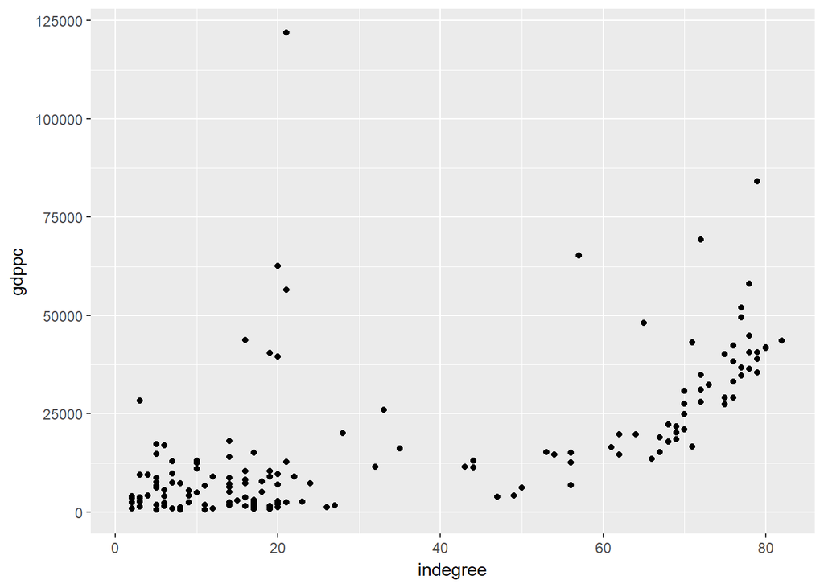

```r
ggplot2::qplot(x = indegree, y = gdppc, data = visa.df) # Some observations are dropped due to NA. Warning messages are suppressed throughout this chapter.
```

In the above example, we have displayed each of our country’s `gdppc` and `indegree` as a point. That was an easy exercise. Still, we can hardly infer from `qplot` what components are part of the graphic. But, again, take some time and think of possible components of the scatterplot. How might we partition the plot into subparts?

Let’s repeat this task using the more powerful `ggplot`-command. In addition, we will explore how to add elements of the grammar each on its own.[^3]

### (1) Data and mapping

First of all, we need **data**. That might sound trivial but it is perfectly fine to create plots without a specific data in mind. For instance, when we intend to apply a graphic to multiple data sets (Wickham 2010: 10). Most times, however, we have a certain data set loaded into our computer’s memory. In our case, we already decided to explore `visa.df`. Hence, the first component that we supply to ggplot is the data. Even though, we won’t see anything when calling the object `visa.plot` now, ggplot already knows our data and converted it accordingly.[^4]

```r
visa.plot <- ggplot(data = visa.df)
```

Next, we have to tell `ggplot` which variables we want to map to the plot. This process is called **mapping** a variable to an **aes**thetic. This is done using the `aes`-function. Here, we map `indegree` to the x-axis and `gdppc` to the y-axis.

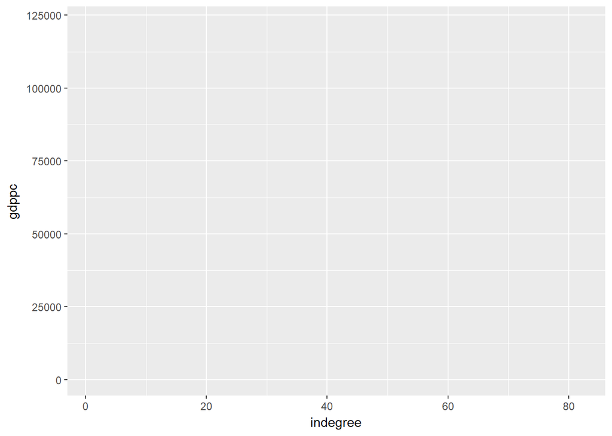

```r
visa.plot <- ggplot(data = visa.df,
                    mapping = aes(x = indegree, y = gdppc))

visa.plot # Calling the created object.
```

Well, we see something but I would refrain from calling it a scatterplot. This is because the aesthetics only tells R what we want to see on the plot. What is still missing is the geometric object that should be used. Still, we finished our first component which consists of data and aesthetic mappings.

### (2) Geometric objects

Geometric objects are added by supplying them using one of the several **geoms** ([Link](http://ggplot2.tidyverse.org/reference/#section-layer-geoms)). A scatterplot, for instance, represents values as points. Hence, we add `geom_point` to our empty plot.

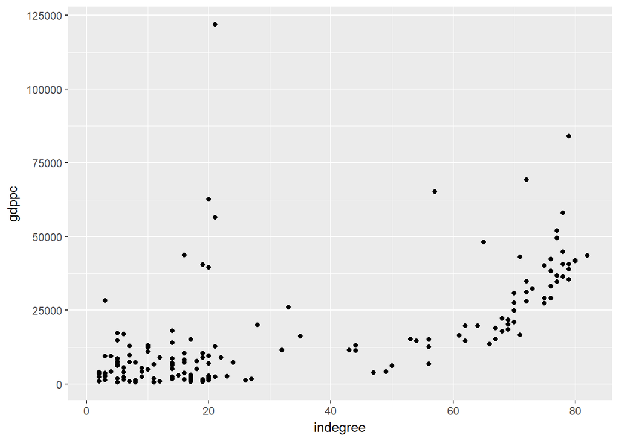

```r
visa.plot <- visa.plot + geom_point() # Adding geom_point to our existing plot.

visa.plot
```

Finally, we arrive at a scatterplot that is identical to the one created above. In addition, we got to know the second component of a graphic named geoms. We used both components to create a valid plot which, however, isn’t always the case:

> In `ggplot2` we can produce many plots that don’t make sense, yet are grammatically valid. This is no different than English, where we can create senseless but grammatical sentences like the angry rock barked like a comma (Wickham 2009: 30).

Let’s try to replace the `geom_point` with another geom:

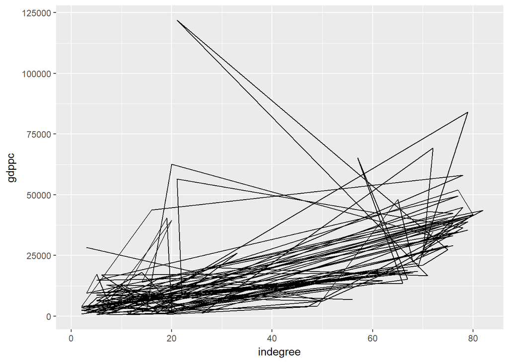

```r
ggplot(data = visa.df,
       mapping = aes(x = indegree, y = gdppc)) +
  geom_path()
```

Doesn’t look quite right - more like “accidental aRt” ([Link](http://accidental-art.tumblr.com/)). The function `geom_path` “connects the observations in the order in which they appear in the data” (see `?geom_path`). This might make sense, however, here it is “senseless”. Still, it shows us how easy it is to experiment with the grammar.

### (3) Scales

Many plots can be created using just the data, aesthetic mappings, geometric objects and leaving the rest to defaults. However, sometimes it is necessary to adjust further components that make up a plot. One of them are **scales**. There is one scale for each aesthetic mapping (in our example both scale are continuous). Scales make sure that we see our data/aesthetics on the plot in a way that we can traverse between data and the “things” we see on the plot. For instance, when displaying the continuous variable GDP, it is necessary that a continuous scale is picked. Still, discrete scales, of course, also exist. Either way, scales are commonly picked automatically but we have some options available. For instance, we could add `scale_y_log10` to use a logarithmic scale which is often helpful when the data is clustered at a certain point of our figure.

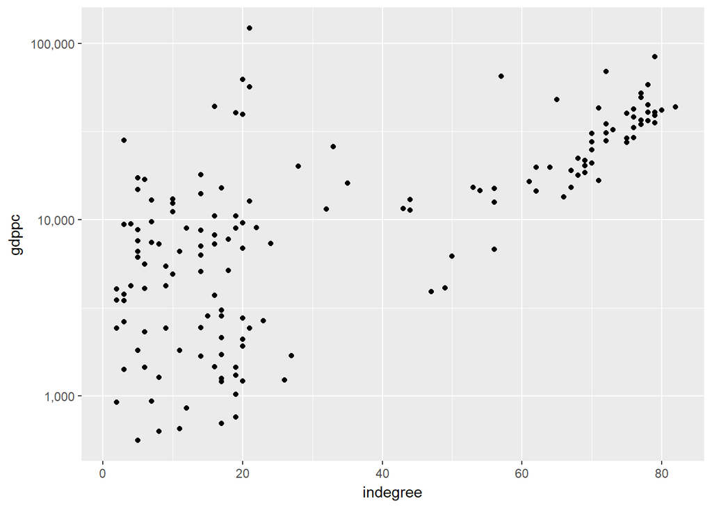

```r
ggplot(data = visa.df,
       mapping = aes(x = indegree, y = gdppc)) +
  geom_point() +
  scale_y_log10(labels = comma) # "labels = comma" prevents the use of scientific notation.
```

### (4) Coordinates

Another component are **coordinate systems** which “control how the axes and grid lines are drawn” (Wickham 2010: 13). Even more so than scales, they are rarely changed. The most common coordinate system is the Cartesian one. The pie chart, though, requires polar coordinates. Finally, geographic coordinate systems are also becoming more common.

### (5) Statistical transformations

Statistical transformations are necessary for certain plots such as the histogram which displays continuous data in bins of height equal to the points that fall into each bin. Here is an example:

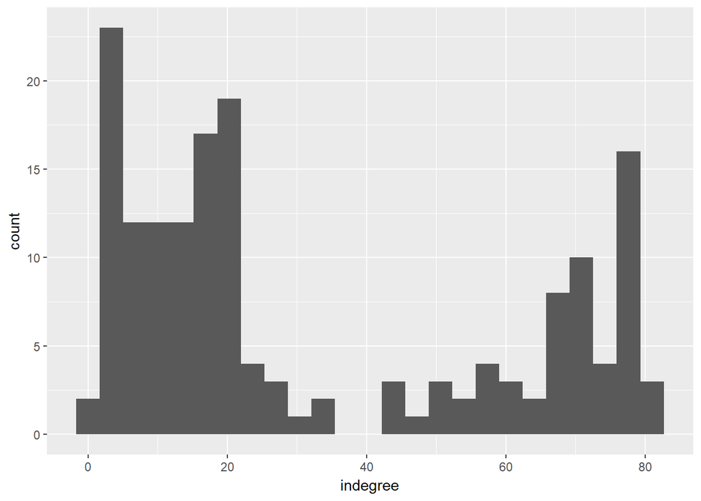

```r
ggplot(data = visa.df,
       mapping = aes(x = indegree)) +
  geom_histogram(stat = "bin", bins = 25)
```

When you need a certain statistical transformation which is not supplied, you can just create it in advance using the techniques we have discussed in the session on `dplyr`. By the way, how would you interpret the histogram in the figure? Is there something striking?

### (6) Facetting

Facetting is used to create what Tufte (1983[1997]: 161ff.) called “small multiples”. Suppose we want to examine the relationship between out two variables for different continents. We have, at least, two options:

1. Adding another variable to our scatterplot above:

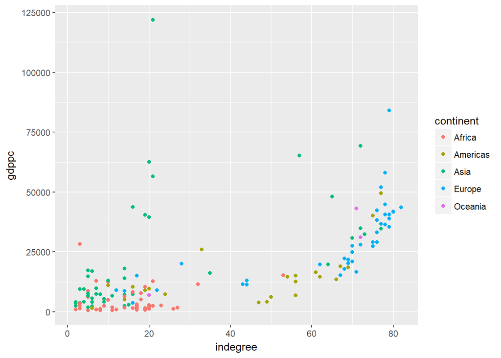

```r
ggplot(data = visa.df,
       mapping = aes(x = indegree, y = gdppc)) +
  geom_point(mapping = aes(color = continent))
```

Besides the fact that Europe seems to fare well in regard to GDP and visa waivers, there is not much we can discern in the plot. Our second option is the following one:

2. Using facetting to display small multiples according to the continent:

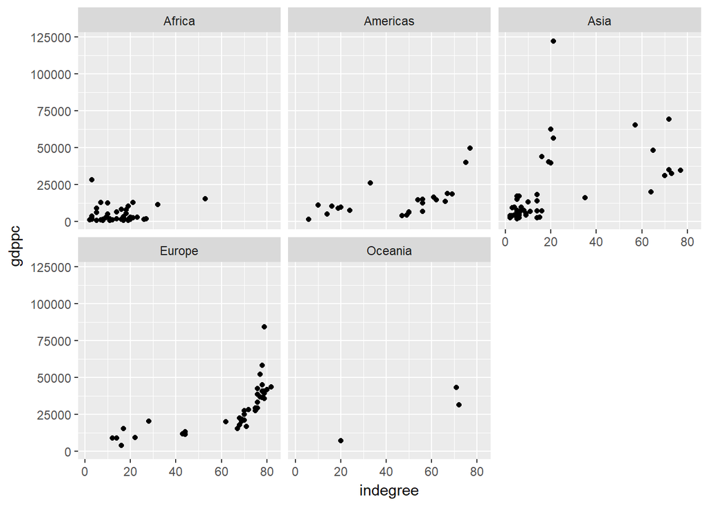

```r
ggplot(data = visa.df,
       mapping = aes(x = indegree, y = gdppc)) +
  geom_point() +
  facet_wrap(facets = ~continent)
```

The facetting splits up the former plot into a series of small multiples that display the relation of GDP and indegree across the variable continent. In this way, we take advantage of the fact that such plots are “inevitably comparative” (Tufte 1983[1997]: 175).

### Conclusion

In this session, we have started to visualize data using the layered grammar of graphics. Even though, we have not yet made use of more than one layer. As an additional read, I suggest chapter 3 of Kieran Healy’s “Data Visualization for Social Science” ([Link](http://socviz.co/makeplot.html)). Many parts we have covered today are repeated there. In this way, you can consolidate your knowledge of ggplot2.

## Bibliography

Harris, Robert L. (1999): Information Graphics. A Comprehensive Illustrated Reference, New York: Oxford University Press.

Wickham, Hadley (2010): A Layered Grammar of Graphics, Journal of Computational and Graphical Statistics, 19(1): 3-28.

Wilkinson, Leland (1999): The Grammar of Graphics. New York: Springer.

[^1]: Sidenote: When working with R, there is no way to avoid packages written by Hadley Wickham which are sometimes alluded to as the `Hadleyverse` ([link](http://adolfoalvarez.cl/the-hitchhikers-guide-to-the-hadleyverse/)).
[^2]: For a more thorough enumeration of different plots see: Harris (1999).
[^3]: We will seldom use `ggplot2::qplot` as `ggplot2::ggplot` offers more options, demands deliberate decisions, and also offers reasonable defaults.
[^4]: You could type `str(visa.plot)` to see that a list was created that, among other things, entails `visa.df`.